# Community context mediates effects of pollinator loss on seed production.

K. C. Arrowsmith, V. A. Reynolds, H. M Briggs, and B. J. Brosi

```r
knitr::opts_chunk$set(warning = FALSE, message = FALSE)
```

# 1 Overview

This document contains all code necessary to replicate the analyses for the above article. Any questions about this project can be directed to Kaysee Arrowsmith at kcarrows@uw.edu.

## 1.1 Particulars

The data for this analysis come from an experimental bumble bee removal experiment that took place over three years (2011, 2013, and 2014; in 2012, there was a severe drought and we were not able to conduct the experiment) across 14 replicates. Each site had two experimental states (control and manipulation). At each site, we selected focal *Delphinium barbeyi* individuals that were identified with ID numbers (`delph.plant.num`). We further selected specific flowers on that focal individual (`delph.flower.num`) for which we collected and counted seeds. *D. barbeyi* flowers typically produce three carpels, so each selected *D. barbeyi* flower may appear in the dataset up to three times, with each row presenting a separate count of viable seeds produced by that carpel. For each site/state combination, we conducted a pollinator survey, which is summarized in this dataset with *Bombus* richness (`bombus.rich`), abundance (`bombus.abund`, scaled to `bomabund.scale`), and mean fidelity (`mean.fidelity`). The identities of these bees were also considered to determine the relative abundance of long-tongued bees (`prop.long`). For manipulation surveys only, we noted the species of *Bombus* removed (`species.removed`, always the most abundant species from that day’s survey) and the number and relative abundance of that species (`prop.removed`). Once per site (during the control period), we performed a floral survey in which is summarized in these data with the relative abundance of *D. barbeyi* (`prop.delph`) and the similarity between the rest of the floral community and *D. barbeyi* on the morphological axes of color (`color.sim`) and corolla length (`corolla.sim`).

# 2 Load Packages, Functions, Data

```r
library(tidyverse)
library(kableExtra)
library(broom.mixed)
library(glmmTMB)
library(xtable)
library(DHARMa)
library(performance)
library(MASS)
library(RColorBrewer)
theme_set(theme_classic())

# Function to calculate confidence intervals
## https://stackoverflow.com/questions/48612153/how-to-calculate-confidence-intervals-for-a-vector
confidence_interval <- function(vector, interval) {
  # Standard deviation of sample
  vec_sd <- sd(vector)
  # Sample size
  n <- length(vector)
  # Mean of sample
  vec_mean <- mean(vector)
  # Error according to t distribution
  error <- qt((interval + 1)/2, df = n - 1) * vec_sd / sqrt(n)
  # Confidence interval as a vector
  result <- c("lower" = vec_mean - error, "upper" = vec_mean + error)
  return(result)
}

dat <- read.csv("../Data/RMBLseeds-cleaned.csv", stringsAsFactors = F) %>%
  filter(!is.na(viable))
```

# 3 Check Model Assumptions

## 3.1 Overdispersion

We start with a global model using a Poisson distribution and check for overdispersion.

```r
global.mod <- glmmTMB(viable ~
                        prop.removed +
                        bomabund.scale +
                        prop.long +
                        mean.fidelity +
                        prop.delph +
                        color.sim +
                        corolla.sim +
                        prop.removed:bomabund.scale +
                        prop.removed:prop.long +
                        prop.removed:mean.fidelity +
                        prop.removed:prop.delph +
                       prop.removed:color.sim +
                       prop.removed:corolla.sim +
                        (1|site/delph.plant.num/delph.flower.num) +
                        (1|year),
                      data = dat,
                      family = poisson)

check_overdispersion(global.mod)
```

```
## # Overdispersion test
##
##        dispersion ratio =    1.907
##   Pearson's Chi-Squared = 3387.408
##                 p-value =  < 0.001
```

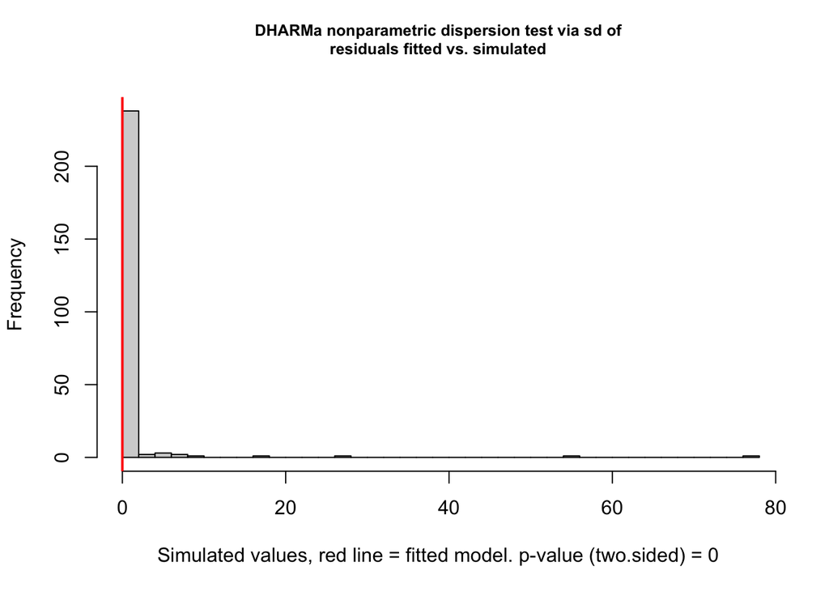

```
##
##  DHARMa nonparametric dispersion test via sd of residuals fitted vs.
##  simulated
##
## data:  simulationOutput
## dispersion = 0.00010848, p-value < 2.2e-16
## alternative hypothesis: two.sided
```

```r
testDispersion(simulateResiduals(global.mod))
```

Significant overdispersion detected (p < 0.05).

To account for overdispersion, we switch from a Poisson distribution to a negative binomial. Next, we check for zero-inflation.

## 3.2 Zero Inflation

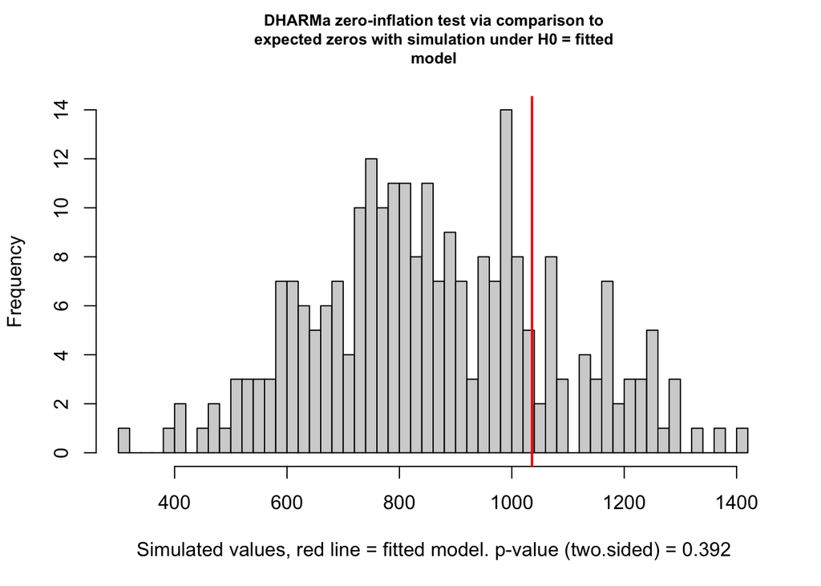

```
##
##  DHARMa zero-inflation test via comparison to expected zeros with
##  simulation under H0 = fitted model
##
## data:  simulationOutput
## ratioObsSim = 1.2058, p-value = 0.392
## alternative hypothesis: two.sided
```

```r
nbinom.mod <- glmmTMB(viable ~
                        prop.removed +
                        bomabund.scale +
                        prop.long +
                        mean.fidelity +
                        prop.delph +
                        color.sim +
                        corolla.sim +
                        prop.removed:bomabund.scale +
                        prop.removed:prop.long +
                        prop.removed:mean.fidelity +
                        prop.removed:prop.delph +
                       prop.removed:color.sim +
                       prop.removed:corolla.sim +
                        (1|site/delph.plant.num/delph.flower.num) +
                        (1|year),
                      data = dat,
                      family = nbinom2)

testZeroInflation(simulateResiduals(nbinom.mod))
```

Ratio > 1 indicates possible zero-inflation, but the p-value is not significant (p > 0.05), so this test is not definitive. We will therefore use two more methods to try to gain more information. First, we perform a chi-squared test to see if there are more zeros than expected. Then, we use an ANOVA to compare models with and without controlling for zero-inflation.

```r
# Chi-square test for zero-inflation
contingency <- dat %>%
  mutate(value.cut = cut(viable, breaks = c(-1, 0, 50), labels = c("0", ">0"))) %>%
  with(table(value.cut, state, useNA = "ifany"))
chisq.test(contingency, simulate.p.value = T)
```

```
##
##  Pearson's Chi-squared test with simulated p-value (based on 2000
##  replicates)
##
## data:  contingency
## X-squared = 5.8232, df = NA, p-value = 0.01549
```

Chi-squared test is significant (p < 0.05), providing evidence of possible zero-inflation.

```r
# Zero-inflated model
nbinom.zi <- glmmTMB(viable ~
                        prop.removed +
                        bomabund.scale +
                        prop.long +
                        mean.fidelity +
                        prop.delph +
                        color.sim +
                        corolla.sim +
                        prop.removed:bomabund.scale +
                        prop.removed:prop.long +
                        prop.removed:mean.fidelity +
                       prop.removed:prop.delph +
                       prop.removed:color.sim +
                       prop.removed:corolla.sim +
                        (1|site/delph.plant.num/delph.flower.num) +
                        (1|year),
                      data = dat,
                      family = nbinom2,
                     zi = ~.)

# Likelihood Ratio Test
anova(nbinom.mod, nbinom.zi)
```

```
## Data: dat
## Models:
## nbinom.mod: viable ~ prop.removed + bomabund.scale + prop.long + mean.fidelity + , zi=~0, disp=~1
## nbinom.mod:     prop.delph + color.sim + corolla.sim + prop.removed:bomabund.scale + , zi=~., disp=~1
## nbinom.mod:     prop.removed:prop.long + prop.removed:mean.fidelity + prop.removed:prop.delph + , zi=~0, disp=~1
## nbinom.mod:     prop.removed:color.sim + prop.removed:corolla.sim + (1 | , zi=~., disp=~1
## nbinom.mod:     site/delph.plant.num/delph.flower.num) + (1 | year), zi=~0, disp=~1
## nbinom.zi: viable ~ prop.removed + bomabund.scale + prop.long + mean.fidelity + , zi=~., disp=~1
## nbinom.zi:     prop.delph + color.sim + corolla.sim + prop.removed:bomabund.scale + , zi=~0, disp=~1
## nbinom.zi:     prop.removed:prop.long + prop.removed:mean.fidelity + prop.removed:prop.delph + , zi=~., disp=~1
## nbinom.zi:     prop.removed:color.sim + prop.removed:corolla.sim + (1 | , zi=~0, disp=~1
## nbinom.zi:     site/delph.plant.num/delph.flower.num) + (1 | year), zi=~., disp=~1
##            Df    AIC    BIC  logLik deviance  Chisq Chi Df Pr(>Chisq)
## nbinom.mod 19 7146.5 7250.9 -3554.3   7108.5
## nbinom.zi  37 6331.2 6534.4 -3128.6   6257.2 851.33     18  < 2.2e-16 ***
## ---
## Signif. codes:  0 '***' 0.001 '**' 0.01 '*' 0.05 '.' 0.1 ' ' 1
```

AIC is lower for zero-inflated model, and ANOVA is statistically significant (p <<< 0.05).

Altogether, these tests indicate that our data are likely to be zero-inflated and we will therefore use a zero-inflated GLMM with a negative binomial distribution.

Next, we check for collinearity between these variables to ensure that they can all be used in model selection without problems.

## 3.3 Collinearity

```r
check_collinearity(nbinom.zi, component = "zi")
```

```
## # Check for Multicollinearity
##
## Low Correlation
##
##                      Term  VIF Increased SE Tolerance
##            bomabund.scale 2.35         1.53      0.42
##                 prop.long 4.97         2.23      0.20
##             mean.fidelity 3.68         1.92      0.27
##                prop.delph 2.99         1.73      0.33
##                 color.sim 2.62         1.62      0.38
##               corolla.sim 3.36         1.83      0.30
##    prop.removed:color.sim 3.86         1.96      0.26
##  prop.removed:corolla.sim 3.63         1.91      0.28
##
## Moderate Correlation
##
##                     Term  VIF Increased SE Tolerance
##  prop.removed:prop.delph 6.69         2.59      0.15
##
## High Correlation
##
##                         Term    VIF Increased SE Tolerance
##                 prop.removed 265.74        16.30      0.00
##  prop.removed:bomabund.scale  12.20         3.49      0.08
##       prop.removed:prop.long 234.04        15.30      0.00
##   prop.removed:mean.fidelity 348.47        18.67      0.00
```

We see moderate to high correlation between many of the variables involving the manipulation (`prop.removed`), which is expected. Importantly, we see low correlation with all of the additive variables that do not involve the strength of the manipulation. To perform an additional confirmation that there is no collinearity in these additive effects, we can build a GLMM without the interaction terms:

```r
nbinom.zi.noint <- glmmTMB(viable ~
                        prop.removed +
                        bomabund.scale +
                        prop.long +
                        mean.fidelity +
                        prop.delph +
                        color.sim +
                        corolla.sim +
                        (1|site/delph.plant.num/delph.flower.num) +
                        (1|year),
                      data = dat,
                      family = nbinom2,
                     zi = ~.)

check_collinearity(nbinom.zi.noint, component = "zi")
```

```
## # Check for Multicollinearity
##
## Low Correlation
##
##            Term  VIF Increased SE Tolerance
##    prop.removed 1.79         1.34      0.56
##  bomabund.scale 1.42         1.19      0.70
##       prop.long 1.90         1.38      0.53
##   mean.fidelity 1.60         1.27      0.62
##      prop.delph 1.47         1.21      0.68
##       color.sim 1.76         1.33      0.57
##     corolla.sim 1.25         1.12      0.80
```

# 4 Main Analysis

## 4.1 Model Selection

We use a model selection approach to determine which fixed effects are most important in predicting the number of viable seeds produced by *D. barbeyi*.

```r
# Creating all combinations of fixed effects and pasting them into a formula
vars <- c("viable",
          "prop.removed",
          "bomabund.scale",
          "prop.long",
          "mean.fidelity",
          "prop.delph",
          "color.sim",
          "corolla.sim",
          "prop.removed:bomabund.scale",
          "prop.removed:prop.long",
          "prop.removed:mean.fidelity",
          "prop.removed:color.sim",
          "prop.removed:corolla.sim",
          "prop.removed:prop.delph"
          )
N <- as.list(seq(1:(length(vars)-1)))
COMB <- sapply(N, function(m) combn(x=vars[2:length(vars)], m))
COMB2 <- list()
k=0
for(i in seq(COMB)){
    tmp <- COMB[[i]]
    for(j in seq(ncol(tmp))){
        k <- k + 1
        COMB2[[k]] <- formula(paste(
          "viable",
          "~",
          paste(tmp[,j], collapse=" + "),
          "+ (1|site/delph.plant.num/delph.flower.num) + (1|year)"))
    }
}

# Running glmmTMB for each formula and using glance to isolate AIC values
res <- vector(mode = "list", length(COMB2))
suppressWarnings(for(i in seq(COMB2)){
    res[[i]] <- try(glance(try(glmmTMB(COMB2[[i]], data=dat, family = nbinom2, zi = ~.))))
})

# Add Model ID column
ID <- c(1:length(res))
res2 <- mapply(cbind, res, "Model" = ID, SIMPLIFY = F)

# Removing models that failed to converge
filt <- Filter(function(x) length(x) > 4, res2)

# Extracting AIC
filt.df <- data.frame(matrix(unlist(filt), nrow = length(filt), byrow = T))
filt.df[,c('X1', 'X2', 'X4', 'X5')] <- list(NULL)
names(filt.df)[names(filt.df) == 'X3'] <- 'AIC'
names(filt.df)[names(filt.df) == 'X6'] <- 'Model'

# Arranging AICs in increasing order
filt.df <- arrange(filt.df, AIC)
filt.df$delta <- filt.df$AIC - filt.df[1,1]

# Filter out only model outputs with delta < 2
filt.2 <- filt.df[filt.df$delta < 2,]

# Taking the Model IDs from the "best" models (delta < 2) and connecting them with the actual formulas
forms <- data.frame(matrix(unlist(COMB2), nrow = length(COMB2), byrow = T))
colnames(forms) <- "Formula"

forms$Model <- c(1:length(res))
forms$Model <- as.numeric(forms$Model)

mods <- merge(filt.2, forms, by = "Model")
mods <- arrange(mods, AIC)
mods$Formula <- as.character(mods$Formula)

mods %>%
  kable %>%
  kable_styling("striped", full_width = T)
```

| Model | AIC | delta | Formula |
| --- | --- | --- | --- |
| 5147 | 6317.690 | 0.0000000 | viable ~ bomabund.scale + prop.long + prop.delph + color.sim + corolla.sim + prop.removed:bomabund.scale + prop.removed:mean.fidelity + (1 \| site/delph.plant.num/delph.flower.num) + (1 \| year) |
| 5812 | 6317.992 | 0.3012489 | viable ~ prop.removed + bomabund.scale + prop.long + mean.fidelity + prop.delph + color.sim + corolla.sim + prop.removed:bomabund.scale + (1 \| site/delph.plant.num/delph.flower.num) + (1 \| year) |
| 6605 | 6318.005 | 0.3143809 | viable ~ bomabund.scale + prop.long + mean.fidelity + prop.delph + color.sim + corolla.sim + prop.removed:bomabund.scale + prop.removed:mean.fidelity + (1 \| site/delph.plant.num/delph.flower.num) + (… |
| 1406 | 6318.274 | 0.5840295 | viable ~ prop.removed + mean.fidelity + color.sim + corolla.sim + prop.removed:bomabund.scale + (1 \| site/delph.plant.num/delph.flower.num) + (1 \| year) |
| 7103 | 6318.555 | 0.8644367 | viable ~ prop.removed + bomabund.scale + prop.long + mean.fidelity + prop.delph + color.sim + corolla.sim + prop.removed:bomabund.scale + prop.removed:prop.delph + (1 \| site/delph.plant.num/delph.flo… |
| 6604 | 6318.711 | 1.0210052 | viable ~ bomabund.scale + prop.long + mean.fidelity + prop.delph + color.sim + corolla.sim + prop.removed:bomabund.scale + prop.removed:prop.long + (1 \| site/delph.plant.num/delph.flower.num) + (1 \|… |
| 5146 | 6318.729 | 1.0382796 | viable ~ bomabund.scale + prop.long + prop.delph + color.sim + corolla.sim + prop.removed:bomabund.scale + prop.removed:prop.long + (1 \| site/delph.plant.num/delph.flower.num) + (1 \| year) |
| 6736 | 6318.879 | 1.1885198 | viable ~ bomabund.scale + prop.long + prop.delph + color.sim + corolla.sim + prop.removed:bomabund.scale + prop.removed:mean.fidelity + prop.removed:prop.delph + (1 \| site/delph.plant.num/delph.flowe… |
| 2738 | 6319.141 | 1.4507387 | viable ~ prop.removed + prop.long + mean.fidelity + color.sim + corolla.sim + prop.removed:bomabund.scale + (1 \| site/delph.plant.num/delph.flower.num) + (1 \| year) |
| 4124 | 6319.284 | 1.5940132 | viable ~ prop.removed + bomabund.scale + prop.long + mean.fidelity + color.sim + corolla.sim + prop.removed:bomabund.scale + (1 \| site/delph.plant.num/delph.flower.num) + (1 \| year) |
| 2185 | 6319.435 | 1.7450732 | viable ~ mean.fidelity + color.sim + corolla.sim + prop.removed:bomabund.scale + prop.removed:mean.fidelity + (1 \| site/delph.plant.num/delph.flower.num) + (1 \| year) |
| 4180 | 6319.501 | 1.8110604 | viable ~ prop.removed + bomabund.scale + prop.long + prop.delph + color.sim + corolla.sim + prop.removed:bomabund.scale + (1 \| site/delph.plant.num/delph.flower.num) + (1 \| year) |
| 5077 | 6319.531 | 1.8405911 | viable ~ bomabund.scale + prop.long + mean.fidelity + color.sim + corolla.sim + prop.removed:bomabund.scale + prop.removed:mean.fidelity + (1 \| site/delph.plant.num/delph.flower.num) + (1 \| year) |
| 2528 | 6319.537 | 1.8468753 | viable ~ prop.removed + bomabund.scale + mean.fidelity + color.sim + corolla.sim + prop.removed:bomabund.scale + (1 \| site/delph.plant.num/delph.flower.num) + (1 \| year) |
| 4558 | 6319.661 | 1.9711193 | viable ~ prop.removed + prop.long + mean.fidelity + prop.delph + color.sim + corolla.sim + prop.removed:bomabund.scale + (1 \| site/delph.plant.num/delph.flower.num) + (1 \| year) |
| 7600 | 6319.682 | 1.9914370 | viable ~ bomabund.scale + prop.long + mean.fidelity + prop.delph + color.sim + corolla.sim + prop.removed:bomabund.scale + prop.removed:mean.fidelity + prop.removed:prop.delph + (1 \| site/delph.plant… |

## 4.2 Model Averaging

Because we do not have an obvious “best” model after model selection, we average all models with ($\Delta AIC < 2$).

```r
form.list <- as.list(rep(NA, times = nrow(mods)))
for(i in 1:nrow(mods)) {
  form.list[[i]] = glmmTMB(as.formula(mods$Formula[i]), data = dat, family = nbinom2, zi = ~.)
}

# Model average
top.avg <- model.avg(form.list)
top.avg
```

```
##
## Call:
## model.avg(object = form.list)
##
## Component models:
## '1/2/3/5/6/8/9/10/12/13/15/16/19/20'
## '2/3/4/7/9/10/11/14/15/19'
## '1/2/3/4/5/6/7/8/9/10/11/12/13/14/15/19'
## '1/2/3/4/5/6/8/9/10/11/12/13/15/16/19/20'
## '1/2/3/5/6/8/9/10/12/13/15/18/19/22'
## '1/2/3/4/5/6/7/8/9/10/11/12/13/14/15/17/19/21'
## '1/2/3/4/5/6/8/9/10/11/12/13/15/18/19/22'
## '1/2/3/5/6/8/9/10/12/13/15/16/17/19/20/21'
## '2/3/4/6/7/9/10/11/13/14/15/19'
## '2/3/4/9/10/11/15/16/19/20'
## '1/2/3/4/6/7/8/9/10/11/13/14/15/19'
## '1/2/3/4/7/8/9/10/11/14/15/19'
## '1/2/3/5/6/7/8/9/10/12/13/14/15/19'
## '1/2/3/4/6/8/9/10/11/13/15/16/19/20'
## '2/3/4/5/6/7/9/10/11/12/13/14/15/19'
## '1/2/3/4/5/6/8/9/10/11/12/13/15/16/17/19/20/21'
##
## Coefficients:
##        cond((Int)) cond(bomabund.scale) cond(prop.long) cond(prop.delph)
## full      2.277258            0.1503960      -0.6648009        0.4981928
## subset    2.277258            0.1981784      -0.8204219        0.7549813
##        cond(color.sim) cond(corolla.sim) cond(bomabund.scale:prop.removed)
## full          1.567684         0.7256633                         0.1773814
## subset        1.567684         0.7256633                         0.1773814
##        cond(mean.fidelity:prop.removed)  zi((Int)) zi(bomabund.scale)
## full                          0.1344819 -0.9821282         -0.1347679
## subset                        0.3462848 -0.9821282         -0.1775850
##        zi(prop.long) zi(prop.delph) zi(color.sim) zi(corolla.sim)
## full       -1.339809      0.4468753     -0.609255        1.657248
## subset     -1.653440      0.6772126     -0.609255        1.657248
##        zi(bomabund.scale:prop.removed) zi(mean.fidelity:prop.removed)
## full                         -3.856683                       1.627521
## subset                       -3.856683                       4.190793
##        cond(prop.removed) cond(mean.fidelity) cond(bomabund.scale:prop.removed)
## full           0.06727994          -0.4975555                         0.1773814
## subset         0.13917570          -0.6895550                         0.1773814
##        zi(prop.removed) zi(mean.fidelity) zi(bomabund.scale:prop.removed)
## full           1.744890          2.121317                       -3.856683
## subset         3.609489          2.939902                       -3.856683
##        cond(mean.fidelity:prop.removed) zi(mean.fidelity:prop.removed)
## full                          0.1344819                       1.627521
## subset                        0.3462848                       4.190793
##        cond(prop.long:prop.removed) zi(prop.long:prop.removed)
## full                     0.04502911                  0.5281062
## subset                   0.35116852                  4.1185418
##        cond(prop.delph:prop.removed) zi(prop.delph:prop.removed)
## full                     -0.09355757                  -0.6553144
## subset                   -0.59690857                  -4.1809850
##        cond(prop.delph:prop.removed) zi(prop.delph:prop.removed)
## full                     -0.09355757                  -0.6553144
## subset                   -0.59690857                  -4.1809850
```

These results are more cleanly shown below in the formatted tables.

# 5 Supporting Analysis

Below are some additional tests that we performed in order to draw various connections and conclusions in our manuscript.

## 5.1 Effect of Manipulation on Bombus Community

We test whether our manipulation has a significant impact on *Bombus* abundance.

```r
bombus.summary <- dat %>%
  group_by(site, state, year) %>%
  summarise(prop.removed = unique(prop.removed),
            bombus.abund = unique(bombus.abund),
            prop.long = unique(prop.long))

rem.abund <- glmmTMB(bombus.abund ~ prop.removed + (1|site) + (1|year), data = bombus.summary, family = poisson)
summary(rem.abund)
```

```
##  Family: poisson  ( log )
## Formula:          bombus.abund ~ prop.removed + (1 | site) + (1 | year)
## Data: bombus.summary
##
##      AIC      BIC   logLik deviance df.resid
##    302.5    307.8   -147.2    294.5       24
##
## Random effects:
##
## Conditional model:
##  Groups Name        Variance Std.Dev.
##  site   (Intercept) 0.26066  0.5105
##  year   (Intercept) 0.01764  0.1328
## Number of obs: 28, groups:  site, 14; year, 3
##
## Conditional model:
##              Estimate Std. Error z value Pr(>|z|)
## (Intercept)   4.04368    0.16095  25.124  < 2e-16 ***
## prop.removed -0.46091    0.09732  -4.736 2.18e-06 ***
## ---
## Signif. codes:  0 '***' 0.001 '**' 0.01 '*' 0.05 '.' 0.1 ' ' 1
```

The manipulation significantly reduced the abundance of bees in the community compared to the control.

We also run the same analysis to see whether our manipulation significantly impacted the proportion of long-tongued bees in the community.

```r
tongue.test <- glmmTMB(prop.long ~ state + (1|site) + (1|year), data = bombus.summary, family = binomial)
summary(tongue.test)
```

```
##  Family: binomial  ( logit )
## Formula:          prop.long ~ state + (1 | site) + (1 | year)
## Data: bombus.summary
##
##      AIC      BIC   logLik deviance df.resid
##     43.4     48.7    -17.7     35.4       24
##
## Random effects:
##
## Conditional model:
##  Groups Name        Variance  Std.Dev.
##  site   (Intercept) 7.627e-10 2.762e-05
##  year   (Intercept) 1.580e-11 3.975e-06
## Number of obs: 28, groups:  site, 14; year, 3
##
## Conditional model:
##                   Estimate Std. Error z value Pr(>|z|)
## (Intercept)         0.5899     0.5579   1.057     0.29
## statemanipulation   0.2461     0.8062   0.305     0.76
```

There was no significant effect of the manipulation on the proportion of the *Bombus* community with long tongues.

# 6 Figures

Below is the code to produce all figures and tables included in the manuscript.

## 6.1 Model Predictions

Generate model predictions so that our plots will show the trends identified by our model selection and averaging.

```r
pred.dat <- dat %>%
  mutate(viable = predict(top.avg,
                          dat,
                          type =  "zlink", # zero-inflated results
                          full = T,
                          allow.new.levels = F))

# Data for geom_pointrange
pred.sum <- pred.dat %>%
  group_by(site, state, prop.removed, bombus.abund, prop.long, mean.fidelity, prop.delph, corolla.sim) %>%
  summarise(mean.viable = mean(exp(viable), na.rm = T),
            lower.ci = confidence_interval(na.omit(exp(viable)), 0.95)[[1]],
            higher.ci = confidence_interval(na.omit(exp(viable)), 0.95)[[2]])

# Manipulation bins - helpful for plotting a continuous interaction term
manip.bins <- data.frame(site = (pred.sum %>% filter(state == "manipulation"))$site,
                         prop.removed = (pred.sum %>% filter(state == "manipulation"))$prop.removed) %>%
  mutate(bin = ifelse(prop.removed < 0.5, "low", "high"))

manip.low <- manip.bins %>% filter(bin == "low")
manip.high <- manip.bins %>% filter(bin == "high")

pred.dat <- pred.dat %>%
  left_join(manip.bins, by = c("site", "prop.removed")) %>%
  mutate(bin = ifelse(is.na(bin), "control", bin))

pred.sum <- pred.sum %>%
  left_join(manip.bins, by = c("site", "prop.removed")) %>%
  mutate(bin = ifelse(is.na(bin), "control", bin))
```

## 6.2 Table 1

Table 1 was created by hand and involves no code.

## 6.3 Table 2

```r
tongue.dat <- data.frame(bombus = c("Bombus appositus",
                                    "Bombus bifarius",
                                    "Bombus californicus",
                                    "Bombus flavifrons",
                                    "Bombus frigidus",
                                    "Bombus kirbiellus",
                                    "Bombus mixtus",
                                    "Bombus nevadensis",
                                    "Bombus occidentalis",
                                    "Bombus rufocinctus",
                                    "Bombus sylvicola"),
                         tongue.length = c("long", "medium", "long", "medium", "medium", "long", "medium", "long", "short", "short", "medium"))

table2 <- dat %>%
  filter(state != "control") %>%
  group_by(site, state, year) %>%
  summarise(species.removed = unique(species.removed),
            prop.removed = max(prop.removed),
            prop.delph = unique(prop.delph)) %>%
  left_join(tongue.dat, by = c("species.removed" = "bombus")) %>%
  arrange(year) %>%
  ungroup() %>%
  dplyr::select(site, year, prop.delph, prop.removed, species.removed, tongue.length)

table2 %>%
  kable() %>%
  kable_styling("striped", full_width = T)
```

| site | year | prop.delph | prop.removed | species.removed | tongue.length |
| --- | --- | --- | --- | --- | --- |
| Brush Creek Fork | 2011 | 0.5666087 | 0.5200000 | Bombus appositus | long |
| Deer Creek Gate 2 | 2011 | 0.1390160 | 0.3571429 | Bombus nevadensis | long |
| Gothic Road Grate.2011 | 2011 | 0.1711975 | 0.4594595 | Bombus appositus | long |
| Gothic Town | 2011 | 0.4381538 | 0.3000000 | Bombus appositus | long |
| Teocali View | 2011 | 0.1911608 | 0.3750000 | Bombus nevadensis | long |
| Back of Baldy Bend | 2013 | 0.0405495 | 0.5000000 | Bombus flavifrons | medium |
| Emerald Lake 2 | 2013 | 0.0726925 | 0.4883721 | Bombus kirbiellus | long |
| Gothic Road 2 | 2013 | 0.0874804 | 0.6009615 | Bombus appositus | long |
| Judd Falls TH 2 | 2013 | 0.1918133 | 0.4754098 | Bombus flavifrons | medium |
| Past Rustlers | 2013 | 0.1676446 | 0.4266667 | Bombus flavifrons | medium |
| Brush Creek Sign | 2014 | 0.4776090 | 0.6562500 | Bombus appositus | long |
| Cold Springs Ranch | 2014 | 0.7139811 | 0.6176471 | Bombus appositus | long |
| Emerald Lake | 2014 | 0.1638344 | 0.5263158 | Bombus kirbiellus | long |
| Gothic Road Grate.2014 | 2014 | 0.2253277 | 0.5172414 | Bombus appositus | long |

```r
# print(xtable(table2, type = "latex"), include.rownames = F, file = "../Figures/SiteSumTable.tex")
```

## 6.4 Table 3

```r
# Run all of the models that the model selection identified
## Create a list with all of the model estimates extracted using tidy
## Filter only the zero-inflated estimates
top.mods <- vector(mode = "list", length(mods$Formula))
for(i in seq(mods$Formula)){
    top.mods[[i]] <-
      tidy(glmmTMB(as.formula(mods$Formula[[i]]), data = dat, family = nbinom2, zi = ~.)) %>%
      filter(component == "zi") %>%
      mutate(var = ifelse(term == "sd__(Intercept)", group, term)) %>%
      dplyr::select(var, estimate) %>%
      pivot_wider(names_from = var, values_from = estimate)
}

# Turn the list of estimates for each model into a single dataframe
modselect.results <- data.frame()
temp.df <- data.frame()
for(i in seq(top.mods)){
  temp.df <- as.data.frame(unlist(top.mods[[i]]))
  colnames(temp.df) <- "estimate"
  temp.df$var <- rownames(temp.df)
  temp.wide <- pivot_wider(temp.df, names_from = var, values_from = estimate)
  modselect.results <- bind_rows(modselect.results, temp.wide)
}

# Add model number to this dataframe
modselect.results$Model <- mods$Model

# Merge the two formats of interaction columns
## Don't need to do this for prop.removed:prop.long since all the necessary info is already in one column
modselect.results <- modselect.results %>%
  mutate(`prop.removed:prop.delph` = ifelse(is.na(`prop.removed:prop.delph`), `prop.delph:prop.removed`, `prop.removed:prop.delph`))

# Reorganize this table and change variable naming convention
modselect.table <- modselect.results %>%
  dplyr::select(Model,
         `(Intercept)`,
         prop.removed,
         bomabund.scale,
         mean.fidelity,
         prop.long,
         prop.delph,
         color.sim,
         corolla.sim,
         `prop.removed:bomabund.scale`,
         `prop.long:prop.removed`,
         `prop.removed:mean.fidelity`,
         `prop.removed:prop.delph`)

modselect.tex <- modselect.table %>%
  left_join(mods, by = "Model") %>%
  dplyr::select(AIC,
         delta,
         prop.removed,
         bomabund.scale,
         prop.long,
         mean.fidelity,
         prop.delph,
         color.sim,
         corolla.sim,
         `prop.removed:bomabund.scale`,
         `prop.long:prop.removed`,
         `prop.removed:mean.fidelity`,
         `prop.removed:prop.delph`) %>%
  mutate(delta = as.character(format(delta, scientific = F, digits = 2))) %>%
  mutate_if(is.numeric, round, digits = 2) %>%
  replace(is.na(.), "")

modselect.tex %>%
  kable() %>%
  kable_styling("striped", full_width = F) %>%
 scroll_box(width = "100%", height = "500px")
```

| AIC | delta | prop.removed | bomabund.scale | prop.long | mean.fidelity | prop.delph | color.sim | corolla.sim | prop.removed:bomabund.scale | prop.long:prop.removed | prop.removed:mean.fidelity | prop.removed:prop.delph |
| --- | --- | --- | --- | --- | --- | --- | --- | --- | --- | --- | --- | --- |
| 6317.69 | 0.00 |  | -0.29 | -1.1 |  | 0.18 | -0.45 | 1.46 |  |  | 3.72 |  |
| 6317.99 | 0.30 | 3.39 | -0.12 | -1.52 | 3.44 | 0.51 | -0.63 | 1.78 | -3.77 |  |  |  |
| 6318.00 | 0.31 |  | -0.17 | -1.64 | 2.58 | 0.58 | -0.67 | 1.70 |  |  |  |  |
| 6318.27 | 0.58 | 3.19 |  |  | 2.89 |  | -0.49 | 1.58 | -3.95 |  |  |  |
| 6318.55 | 0.86 | 5.73 | 0.06 | -3.01 | 3.65 | 1.96 | -0.83 | 1.99 | -4.9 |  |  | -4.79 |
| 6318.71 | 1.02 |  | -0.16 | -1.8 | 2.77 | 0.57 | -0.49 | 1.73 |  | 4.18 |  |  |
| 6318.73 | 1.04 |  | -0.3 | -1.19 |  | 0.13 | -0.27 | 1.47 |  | 4.06 |  |  |
| 6318.88 | 1.19 |  | -0.16 | -2.45 |  | 1.46 | -0.67 | 1.62 |  |  | 5.84 | -3.99 |
| 6319.14 | 1.45 | 3.51 |  | -1.49 | 3.38 |  | -1.01 | 1.80 | -3.94 |  |  |  |
| 6319.28 | 1.59 | 3.35 | -0.14 | -1.38 | 3.2 |  | -0.83 | 1.77 | -3.79 |  |  |  |
| 6319.44 | 1.75 |  |  |  | 2.1 |  | -0.61 | 1.50 | -3.62 |  |  |  |
| 6319.50 | 1.81 | 3.07 | -0.31 | -0.69 |  | -0.04 | -0.37 | 1.46 | -4.11 |  |  |  |
| 6319.53 | 1.84 |  | -0.19 | -1.48 | 2.33 |  | -0.90 | 1.68 |  |  |  |  |
| 6319.54 | 1.85 | 2.97 | -0.22 |  | 2.63 |  | -0.25 | 1.55 | -3.72 |  |  |  |
| 6319.66 | 1.97 | 3.53 |  | -1.62 | 3.59 | 0.53 | -0.78 | 1.81 | -3.9 |  |  |  |
| 6319.68 | 1.99 |  | -0.07 | -2.74 | 2.32 | 1.64 | -0.84 | 1.80 |  |  |  | -3.42 |

```r
# print(xtable(modselect.tex, type = "latex"), file = "../Data/ModelSelectionTable.tex")
```

## 6.5 Table 4

```r
# Some formatting to make the table look nice
avg.table <- as.data.frame(summary(top.avg)[9]) %>%
  rownames_to_column(var = "variable") %>%
  filter(str_detect(variable, "zi"),
         str_detect(variable, "1", negate = T))

avg.rownames <- data.frame(variable = avg.table$variable,
                           formatted = c("Intercept",
                                         "BA",
                                         "PL",
                                         "PD",
                                         "CL",
                                         "CR",
                                         "PR:BA",
                                         "PR:MF",
                                         "PR",
                                         "MF",
                                         "PR:PL",
                                         "PR:PD"))


avg.table <- avg.table %>%
  left_join(avg.rownames, by = "variable") %>%
  dplyr::select(-variable) %>%
  column_to_rownames(var = "formatted") %>%
  rename("Estimate" = "coefmat.full.Estimate",
         "Std.Error" = "coefmat.full.Std..Error",
         "Adjusted.SE" = "coefmat.full.Adjusted.SE",
         "z-value" = "coefmat.full.z.value",
         "p-value" = "coefmat.full.Pr...z..")

avgtable.tex <- avg.table %>%
  mutate(arrange.key = c(1, 3, 4, 6, 7, 8, 9, 11, 2, 5, 10, 12)) %>%
  arrange(arrange.key) %>%
  dplyr::select(-arrange.key)

avgtable.tex %>%
  kable() %>%
  kable_styling("striped", full_width = T)
```

|  | Estimate | Std.Error | Adjusted.SE | z-value | p-value |
| --- | --- | --- | --- | --- | --- |
| Intercept | -0.9821282 | 1.8617146 | 1.8623667 | 0.5273549 | 0.5979472 |
| PR | 1.7448895 | 2.0129621 | 2.0131175 | 0.8667599 | 0.3860736 |
| BA | -0.1347679 | 0.2775273 | 0.2776843 | 0.4853276 | 0.6274440 |
| PL | -1.3398090 | 1.3656800 | 1.3662575 | 0.9806416 | 0.3267695 |
| MF | 2.1213168 | 1.8793896 | 1.8799820 | 1.1283708 | 0.2591634 |
| PD | 0.4468753 | 1.0042241 | 1.0046728 | 0.4447968 | 0.6564666 |
| CL | -0.6092550 | 1.1370887 | 1.1378416 | 0.5354480 | 0.5923401 |
| CR | 1.6572481 | 0.5288371 | 0.5291694 | 3.1317912 | 0.0017374 |
| PR:BA | -3.8566826 | 0.9778549 | 0.9784187 | 3.9417506 | 0.0000809 |
| PR:PL | 0.5281062 | 1.4325124 | 1.4325868 | 0.3686382 | 0.7123974 |
| PR:MF | 1.6275205 | 2.2400225 | 2.2401893 | 0.7265103 | 0.4675260 |
| PR:PD | -0.6553144 | 1.8626240 | 1.8630337 | 0.3517459 | 0.7250289 |

```r
# print(xtable(avgtable.tex, type = "latex"), row.names = F, file = "../Data/AverageTable.tex")
```

## 6.6 Figure 1

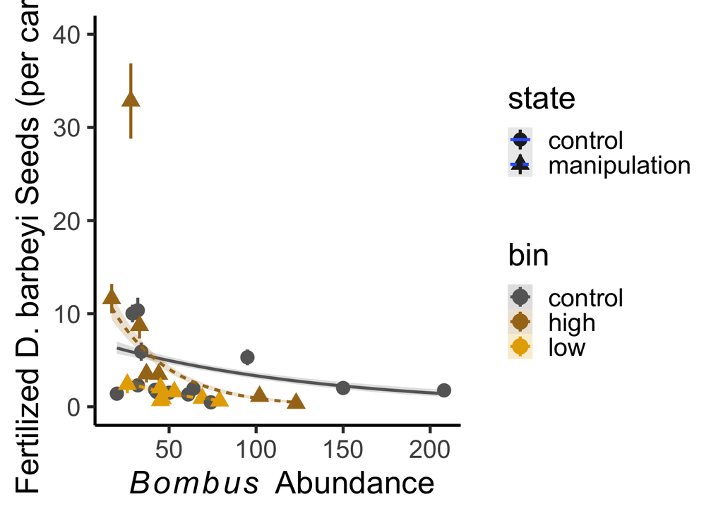

```r
abund.all <- ggplot() +
  geom_pointrange(data = pred.sum,
                  aes(x = bombus.abund,
                      y = mean.viable,
                      ymax = higher.ci,
                      ymin = lower.ci,
                      col = bin,
                      shape = state),
                  size = 1,
                  linewidth = 1) +
  geom_smooth(data = pred.dat,
              aes(x = bombus.abund,
                  y = exp(viable),
                  col = bin,
                  fill = bin,
                  linetype = state),
              method = "glm.nb",
              se = T,
              alpha = 0.2) +
  scale_color_manual(values = brewer.pal(8, "Dark2")[8:6]) +
  scale_fill_manual(values = brewer.pal(8, "Dark2")[8:6]) +
  labs(x = ~italic(Bombus)~" Abundance",
       y = "Fertilized D. barbeyi Seeds (per carpel)") +
  theme_classic(base_size = 22) +
  lims(y = c(0, 40))

abund.all
```

```r
# ggsave("../Figures/bomabund.png", plot = abund.all, width = 7, height = 10, units = "in")
```

## 6.7 Figure 2

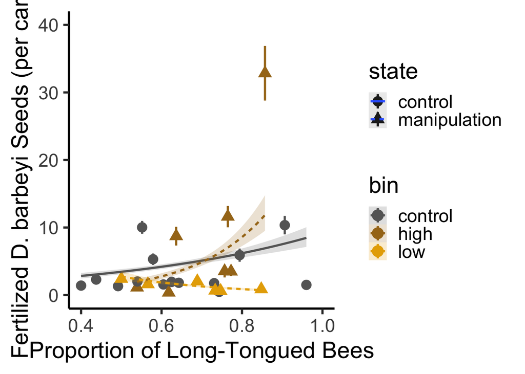

```r
tongue.all <- ggplot() +
  geom_pointrange(data = pred.sum,
                  aes(x = prop.long,
                      y = mean.viable,
                      ymax = higher.ci,
                      ymin = lower.ci,
                      col = bin,
                      shape = state),
                  size = 1,
                  linewidth = 1) +
  geom_smooth(data = pred.dat,
              aes(x = prop.long,
                  y = exp(viable),
                  col = bin,
                  fill = bin,
                  linetype = state),
              method = "glm.nb",
              se = T,
              alpha = 0.2) +
  scale_color_manual(values = brewer.pal(8, "Dark2")[8:6]) +
  scale_fill_manual(values = brewer.pal(8, "Dark2")[8:6]) +
  theme_classic(base_size = 22) +
  labs(x = "Proportion of Long-Tongued Bees",
       y = "Fertilized D. barbeyi Seeds (per carpel)") +
  lims(x = c(0.4, 1),
       y = c(0, 40))

tongue.all
```

```r
# ggsave("../Figures/tongue-length.png", plot = tongue.all, width = 7, height = 10, units = "in")
```

## 6.8 Figure 3

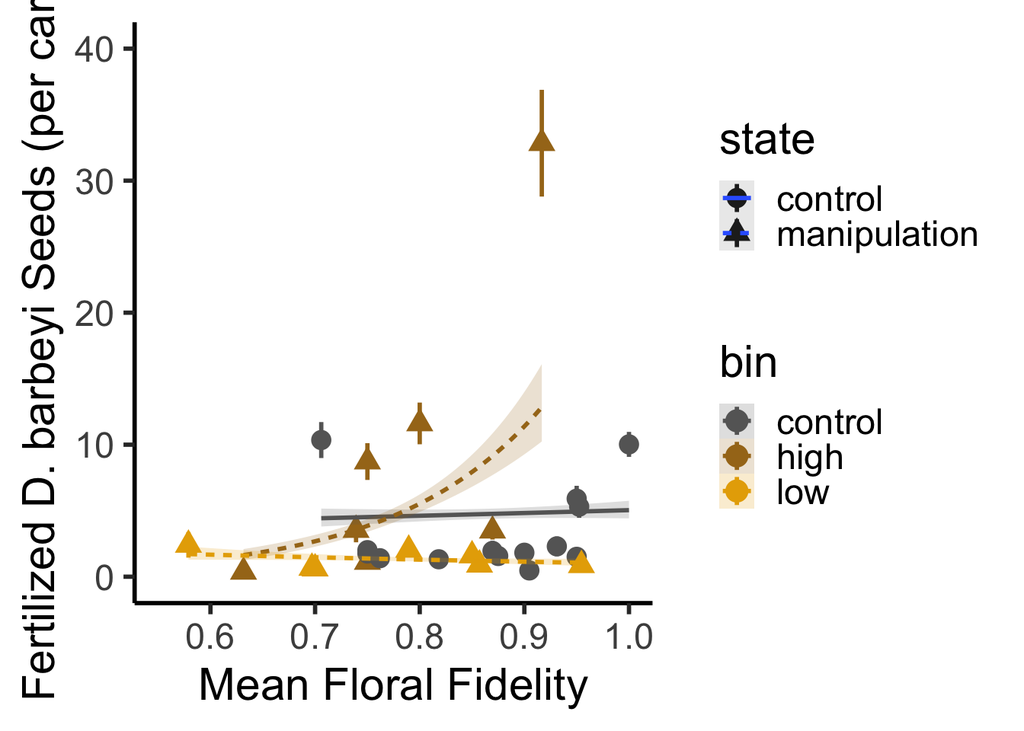

```r
fidelity.all <- ggplot() +
  geom_pointrange(data = pred.sum,
                  aes(x = mean.fidelity,
                      y = mean.viable,
                      ymax = higher.ci,
                      ymin = lower.ci,
                      col = bin,
                      shape = state),
                  size = 1,
                  linewidth = 1) +
  geom_smooth(data = pred.dat,
              aes(x = mean.fidelity,
                  y = exp(viable),
                  col = bin,
                  fill = bin,
                  linetype = state),
              method = "glm.nb",
              se = T,
              alpha = 0.2) +
  scale_color_manual(values = brewer.pal(8, "Dark2")[8:6]) +
  scale_fill_manual(values = brewer.pal(8, "Dark2")[8:6]) +
  theme_classic(base_size = 22) +
  labs(x = "Mean Floral Fidelity",
       y = "Fertilized D. barbeyi Seeds (per carpel)") +
  lims(x = c(0.55, 1),
       y = c(0, 40))
fidelity.all
```

```r
# ggsave("../Figures/fidelity-all.png", plot = fidelity.all, width = 7, height = 10, units = "in")
```

# 7 Supplemental Information

These tables and figures are not included in the manuscript but are made available here in case of interest. Many are in response to reviewer comments.

## 7.1 Annual changes in focal species

### 7.1.1 *D. barbeyi*

```r
db.abund <- dat %>%
  mutate(year = as.character(year)) %>%
  group_by(site, year) %>%
  summarise(num.delph = unique(num.delph),
            prop.delph = unique(prop.delph))

dbabund.test <- aov(num.delph ~ year, family = poisson, data = db.abund)
summary(dbabund.test)
```

```
##             Df   Sum Sq  Mean Sq F value Pr(>F)
## year         2 30800614 15400307   3.582 0.0634 .
## Residuals   11 47292412  4299310
## ---
## Signif. codes:  0 '***' 0.001 '**' 0.01 '*' 0.05 '.' 0.1 ' ' 1
```

```r
propdb.test <- aov(prop.delph ~ year, family = binomial, data = db.abund)
summary(propdb.test)
```

```
##             Df Sum Sq Mean Sq F value Pr(>F)
## year         2 0.1911 0.09553   2.985 0.0921 .
## Residuals   11 0.3520 0.03200
## ---
## Signif. codes:  0 '***' 0.001 '**' 0.01 '*' 0.05 '.' 0.1 ' ' 1
```

Year has a marginally significant effect on *D. barbeyi* abundance and on the proportion of *D. barbeyi* at each site.

### 7.1.2 *Bombus*

```r
bom.abund <- dat %>%
  mutate(year = as.character(year)) %>%
  group_by(site, state, year) %>%
  summarise(bombus.abund = unique(bombus.abund))

bomabund.test <- aov(bombus.abund ~ year, data = bom.abund)
summary(bomabund.test)
```

```
##             Df Sum Sq Mean Sq F value Pr(>F)
## year         2  10009    5004   3.178 0.0589 .
## Residuals   25  39364    1575
## ---
## Signif. codes:  0 '***' 0.001 '**' 0.01 '*' 0.05 '.' 0.1 ' ' 1
```

Year has a marginally significant effect on the overall abundance of *Bombus* in our study system.

## 7.2 *Bombus* Tongue Lengths

```r
tongue.dat %>%
  kable() %>%
  kable_styling("striped", full_width = F)
```

| bombus | tongue.length |
| --- | --- |
| Bombus appositus | long |
| Bombus bifarius | medium |
| Bombus californicus | long |
| Bombus flavifrons | medium |
| Bombus frigidus | medium |
| Bombus kirbiellus | long |
| Bombus mixtus | medium |
| Bombus nevadensis | long |
| Bombus occidentalis | short |
| Bombus rufocinctus | short |
| Bombus sylvicola | medium |

## 7.3 Site-level *Bombus* abundance

```r
bom <- read.csv("../Data/bombus-summary.csv", stringsAsFactors = F)

bom.community <- bom %>%
  pivot_wider(names_from = "bee.sp",
              values_from = "n",
              values_fill = 0)

bom.community %>%
  kable() %>%
  kable_styling("striped", full_width = F) %>%
 scroll_box(width = "100%", height = "500px")
```

| site | state | Bombus appositus | Bombus bifarius | Bombus flavifrons | Bombus kirbiellus | Bombus nevadensis | Bombus californicus | Bombus sylvicola | Bombus occidentalis |
| --- | --- | --- | --- | --- | --- | --- | --- | --- | --- |
| Back of Baldy Bend | control | 10 | 2 | 16 | 2 | 2 | 0 | 0 | 0 |
| Back of Baldy Bend | manipulation | 27 | 0 | 10 | 6 | 1 | 0 | 0 | 0 |
| Brush Creek Fork | control | 26 | 0 | 1 | 0 | 14 | 8 | 1 | 0 |
| Brush Creek Fork | manipulation | 8 | 2 | 6 | 0 | 18 | 2 | 1 | 0 |
| Brush Creek Sign | control | 21 | 3 | 0 | 0 | 7 | 1 | 0 | 0 |
| Brush Creek Sign | manipulation | 12 | 3 | 0 | 0 | 7 | 5 | 1 | 0 |
| Cold Springs Ranch | control | 21 | 7 | 0 | 0 | 5 | 1 | 0 | 0 |
| Cold Springs Ranch | manipulation | 13 | 11 | 1 | 0 | 5 | 3 | 0 | 0 |
| Deer Creek Gate 2 | control | 11 | 9 | 5 | 0 | 15 | 1 | 0 | 1 |
| Deer Creek Gate 2 | manipulation | 15 | 12 | 9 | 0 | 9 | 6 | 0 | 2 |
| Emerald Lake | control | 4 | 5 | 31 | 50 | 1 | 0 | 4 | 0 |
| Emerald Lake | manipulation | 19 | 9 | 32 | 36 | 0 | 0 | 6 | 0 |
| Emerald Lake 2 | control | 5 | 5 | 12 | 21 | 0 | 0 | 0 | 0 |
| Emerald Lake 2 | manipulation | 17 | 7 | 11 | 33 | 1 | 0 | 0 | 0 |
| Gothic Road 2 | control | 125 | 16 | 28 | 3 | 11 | 13 | 12 | 0 |
| Gothic Road 2 | manipulation | 35 | 8 | 29 | 7 | 1 | 33 | 10 | 0 |
| Gothic Road Grate.2011 | control | 34 | 19 | 0 | 0 | 20 | 1 | 0 | 0 |
| Gothic Road Grate.2011 | manipulation | 7 | 6 | 0 | 0 | 27 | 5 | 0 | 1 |
| Gothic Road Grate.2014 | control | 15 | 8 | 0 | 0 | 1 | 0 | 5 | 0 |
| Gothic Road Grate.2014 | manipulation | 5 | 3 | 0 | 0 | 6 | 2 | 1 | 0 |
| Gothic Town | control | 6 | 7 | 3 | 0 | 2 | 0 | 2 | 0 |
| Gothic Town | manipulation | 5 | 5 | 6 | 1 | 26 | 1 | 1 | 0 |
| Judd Falls TH 2 | control | 28 | 0 | 29 | 1 | 1 | 0 | 2 | 0 |
| Judd Falls TH 2 | manipulation | 28 | 1 | 13 | 0 | 0 | 3 | 0 | 0 |
| Past Rustlers | control | 63 | 4 | 64 | 4 | 3 | 11 | 0 | 1 |
| Past Rustlers | manipulation | 36 | 6 | 14 | 8 | 1 | 14 | 0 | 0 |
| Teocali View | control | 15 | 17 | 6 | 0 | 24 | 1 | 1 | 0 |
| Teocali View | manipulation | 9 | 6 | 7 | 0 | 2 | 2 | 0 | 0 |

## 7.4 Relationship between *D. barbeyi* relative abundance and seed production

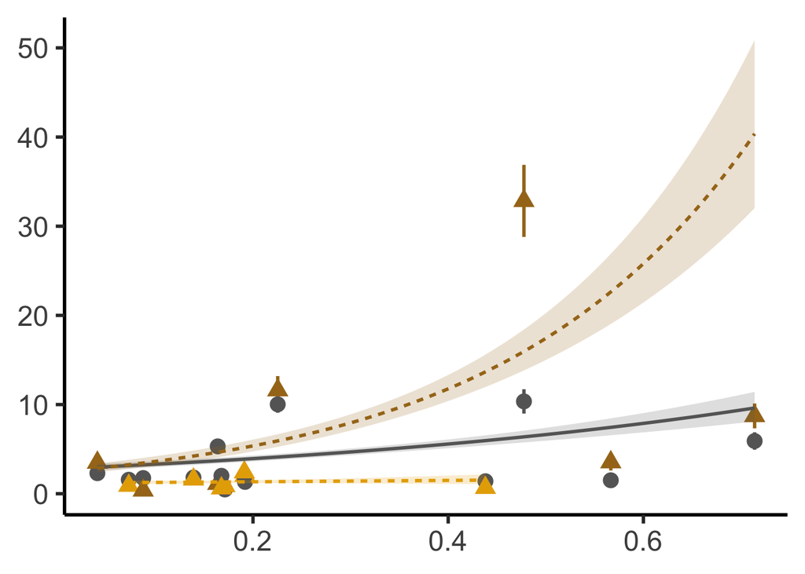

```r
delph.plot <- ggplot() +
  geom_pointrange(data = pred.sum,
                  aes(x = prop.delph,
                      y = mean.viable,
                      ymax = higher.ci,
                      ymin = lower.ci,
                      col = bin,
                      shape = state),
                  size = 1,
                  linewidth = 1) +
  geom_smooth(data = pred.dat,
              aes(x = prop.delph,
                  y = exp(viable),
                  col = bin,
                  fill = bin,
                  linetype = state),
              method = "glm.nb",
              se = T,
              alpha = 0.2) +
  scale_color_manual(values = brewer.pal(8, "Dark2")[8:6]) +
  scale_fill_manual(values = brewer.pal(8, "Dark2")[8:6]) +
  theme_classic(base_size = 22) +
  theme(axis.title = element_blank(),
        legend.position = "none")
delph.plot
```